# Optimal Treatment Analysis

## Outcome Variable

**Outcome Variable:** ever_stunted

## Predictor Variables

**Intervention Variable:** fhtcm

**Adjustment Set:**

- arm
- W_mage
- W_fage
- meducyrs
- feducyrs
- W_mhtcm
- W_mwtkg
- W_mbmi
- single
- delta_W_mage
- delta_W_fage
- delta_meducyrs
- delta_feducyrs
- delta_W_mhtcm
- delta_W_mwtkg
- delta_W_mbmi
- delta_single

## Stratifying Variables

The analysis was stratified on these variable(s):

- agecat
- studyid
- country

## Data Summary

| agecat | studyid | country | fhtcm | ever_stunted | n_cell | n |
| --- | --- | --- | --- | --- | --- | --- |
| 0-24 months | ki1000304b-SAS-CompFeed | INDIA | >=167 cm | 0 | 137 | 907 |
| 0-24 months | ki1000304b-SAS-CompFeed | INDIA | >=167 cm | 1 | 273 | 907 |
| 0-24 months | ki1000304b-SAS-CompFeed | INDIA | <162 cm | 0 | 50 | 907 |
| 0-24 months | ki1000304b-SAS-CompFeed | INDIA | <162 cm | 1 | 180 | 907 |
| 0-24 months | ki1000304b-SAS-CompFeed | INDIA | [162-167) cm | 0 | 69 | 907 |
| 0-24 months | ki1000304b-SAS-CompFeed | INDIA | [162-167) cm | 1 | 198 | 907 |
| 0-24 months | ki1000304b-SAS-FoodSuppl | INDIA | >=167 cm | 0 | 23 | 399 |
| 0-24 months | ki1000304b-SAS-FoodSuppl | INDIA | >=167 cm | 1 | 83 | 399 |
| 0-24 months | ki1000304b-SAS-FoodSuppl | INDIA | <162 cm | 0 | 15 | 399 |
| 0-24 months | ki1000304b-SAS-FoodSuppl | INDIA | <162 cm | 1 | 148 | 399 |
| 0-24 months | ki1000304b-SAS-FoodSuppl | INDIA | [162-167) cm | 0 | 23 | 399 |
| 0-24 months | ki1000304b-SAS-FoodSuppl | INDIA | [162-167) cm | 1 | 107 | 399 |
| 0-24 months | ki1101329-Keneba | GAMBIA | >=167 cm | 0 | 598 | 1929 |
| 0-24 months | ki1101329-Keneba | GAMBIA | >=167 cm | 1 | 647 | 1929 |
| 0-24 months | ki1101329-Keneba | GAMBIA | <162 cm | 0 | 52 | 1929 |
| 0-24 months | ki1101329-Keneba | GAMBIA | <162 cm | 1 | 80 | 1929 |
| 0-24 months | ki1101329-Keneba | GAMBIA | [162-167) cm | 0 | 207 | 1929 |
| 0-24 months | ki1101329-Keneba | GAMBIA | [162-167) cm | 1 | 345 | 1929 |
| 0-24 months | ki1119695-PROBIT | BELARUS | >=167 cm | 0 | 9839 | 12537 |
| 0-24 months | ki1119695-PROBIT | BELARUS | >=167 cm | 1 | 1905 | 12537 |
| 0-24 months | ki1119695-PROBIT | BELARUS | <162 cm | 0 | 119 | 12537 |
| 0-24 months | ki1119695-PROBIT | BELARUS | <162 cm | 1 | 49 | 12537 |
| 0-24 months | ki1119695-PROBIT | BELARUS | [162-167) cm | 0 | 474 | 12537 |
| 0-24 months | ki1119695-PROBIT | BELARUS | [162-167) cm | 1 | 151 | 12537 |
| 0-24 months | ki1135781-COHORTS | GUATEMALA | >=167 cm | 0 | 16 | 496 |
| 0-24 months | ki1135781-COHORTS | GUATEMALA | >=167 cm | 1 | 48 | 496 |
| 0-24 months | ki1135781-COHORTS | GUATEMALA | <162 cm | 0 | 24 | 496 |
| 0-24 months | ki1135781-COHORTS | GUATEMALA | <162 cm | 1 | 269 | 496 |
| 0-24 months | ki1135781-COHORTS | GUATEMALA | [162-167) cm | 0 | 24 | 496 |
| 0-24 months | ki1135781-COHORTS | GUATEMALA | [162-167) cm | 1 | 115 | 496 |

[output cut: 60 more lines]

The following strata were considered:

- agecat: 0-24 months, studyid: ki1000304b-SAS-CompFeed, country: INDIA
- agecat: 0-24 months, studyid: ki1000304b-SAS-FoodSuppl, country: INDIA
- agecat: 0-24 months, studyid: ki1101329-Keneba, country: GAMBIA
- agecat: 0-24 months, studyid: ki1119695-PROBIT, country: BELARUS
- agecat: 0-24 months, studyid: ki1135781-COHORTS, country: GUATEMALA
- agecat: 0-6 months, studyid: ki1000304b-SAS-CompFeed, country: INDIA
- agecat: 0-6 months, studyid: ki1000304b-SAS-FoodSuppl, country: INDIA
- agecat: 0-6 months, studyid: ki1101329-Keneba, country: GAMBIA
- agecat: 0-6 months, studyid: ki1119695-PROBIT, country: BELARUS
- agecat: 0-6 months, studyid: ki1135781-COHORTS, country: GUATEMALA
- agecat: 6-24 months, studyid: ki1000304b-SAS-CompFeed, country: INDIA
- agecat: 6-24 months, studyid: ki1000304b-SAS-FoodSuppl, country: INDIA
- agecat: 6-24 months, studyid: ki1101329-Keneba, country: GAMBIA
- agecat: 6-24 months, studyid: ki1119695-PROBIT, country: BELARUS
- agecat: 6-24 months, studyid: ki1135781-COHORTS, country: GUATEMALA

## Methods Detail

We’re interested in the causal parameters $E[Y_a]$ for all values of $a \in \mathcal{A}$. These parameters represent the mean outcome if, possibly contrary to fact, we intervened to set all units to have $A=a$. Under the randomization and positivity assumptions, these are identified by the statistical parameters $\psi_a=E_W[E_{Y|A,W}(Y|A=a,W)]$. In addition, we’re interested in the mean of $Y$, $E[Y]$ under no intervention (the observed mean). We will estimate these parameters by using SuperLearner to fit the relevant likelihood factors – $E_{Y|A,W}(Y|A=a,W)$ and $p(A=a|W)$, and then updating our likelihood fit using a joint TMLE.

For unadjusted analyses ($W=\{\}$), initial likelihoods were estimated using Lrnr_glm to estimate the simple $E(Y|A)$ and Lrnr_mean to estimate $p(A)$. For adjusted analyses, a small library containing Lrnr_glmnet, Lrnr_xgboost, and Lrnr_mean was used.

Having estimated these parameters, we will then use the delta method to estimate relative risks and attributable risks relative to a prespecified baseline level of $A$.

# Results Detail

## Results Plots

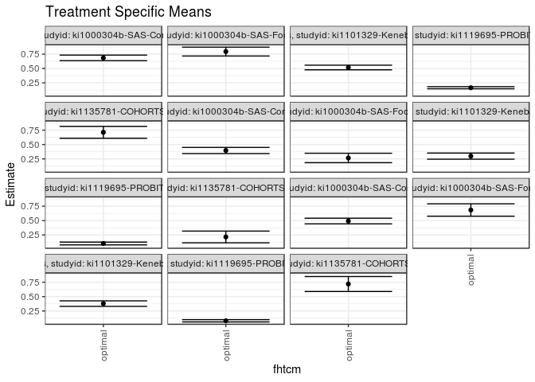

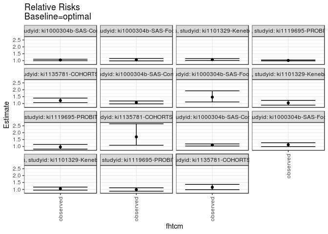

## Results Table

### Parameter: TSM

| agecat | studyid | country | intervention_level | baseline_level | estimate | ci_lower | ci_upper |
| --- | --- | --- | --- | --- | --- | --- | --- |
| 0-24 months | ki1000304b-SAS-CompFeed | INDIA | optimal | NA | 0.6844789 | 0.6360191 | 0.7329388 |
| 0-24 months | ki1000304b-SAS-FoodSuppl | INDIA | optimal | NA | 0.7945229 | 0.7173573 | 0.8716886 |
| 0-24 months | ki1101329-Keneba | GAMBIA | optimal | NA | 0.5173819 | 0.4770125 | 0.5577514 |
| 0-24 months | ki1119695-PROBIT | BELARUS | optimal | NA | 0.1654117 | 0.1469755 | 0.1838480 |
| 0-24 months | ki1135781-COHORTS | GUATEMALA | optimal | NA | 0.7125877 | 0.6091094 | 0.8160659 |
| 0-6 months | ki1000304b-SAS-CompFeed | INDIA | optimal | NA | 0.3964468 | 0.3427979 | 0.4500956 |
| 0-6 months | ki1000304b-SAS-FoodSuppl | INDIA | optimal | NA | 0.2664334 | 0.1844450 | 0.3484218 |
| 0-6 months | ki1101329-Keneba | GAMBIA | optimal | NA | 0.2981726 | 0.2449229 | 0.3514224 |
| 0-6 months | ki1119695-PROBIT | BELARUS | optimal | NA | 0.1012819 | 0.0770980 | 0.1254658 |
| 0-6 months | ki1135781-COHORTS | GUATEMALA | optimal | NA | 0.2149446 | 0.1127610 | 0.3171283 |
| 6-24 months | ki1000304b-SAS-CompFeed | INDIA | optimal | NA | 0.4916908 | 0.4426075 | 0.5407740 |
| 6-24 months | ki1000304b-SAS-FoodSuppl | INDIA | optimal | NA | 0.6838917 | 0.5760196 | 0.7917638 |
| 6-24 months | ki1101329-Keneba | GAMBIA | optimal | NA | 0.3778686 | 0.3299380 | 0.4257991 |
| 6-24 months | ki1119695-PROBIT | BELARUS | optimal | NA | 0.0791277 | 0.0590236 | 0.0992317 |
| 6-24 months | ki1135781-COHORTS | GUATEMALA | optimal | NA | 0.7189645 | 0.5889691 | 0.8489599 |

### Parameter: E(Y)

| agecat | studyid | country | intervention_level | baseline_level | estimate | ci_lower | ci_upper |
| --- | --- | --- | --- | --- | --- | --- | --- |
| 0-24 months | ki1000304b-SAS-CompFeed | INDIA | observed | NA | 0.7177508 | 0.6751525 | 0.7603491 |
| 0-24 months | ki1000304b-SAS-FoodSuppl | INDIA | observed | NA | 0.8471178 | 0.8117623 | 0.8824733 |
| 0-24 months | ki1101329-Keneba | GAMBIA | observed | NA | 0.5557284 | 0.5335489 | 0.5779078 |
| 0-24 months | ki1119695-PROBIT | BELARUS | observed | NA | 0.1679030 | 0.1492221 | 0.1865839 |
| 0-24 months | ki1135781-COHORTS | GUATEMALA | observed | NA | 0.8709677 | 0.8414356 | 0.9004999 |
| 0-6 months | ki1000304b-SAS-CompFeed | INDIA | observed | NA | 0.4265193 | 0.3923837 | 0.4606550 |
| 0-6 months | ki1000304b-SAS-FoodSuppl | INDIA | observed | NA | 0.3904282 | 0.3423793 | 0.4384771 |
| 0-6 months | ki1101329-Keneba | GAMBIA | observed | NA | 0.3116657 | 0.2897893 | 0.3335421 |
| 0-6 months | ki1119695-PROBIT | BELARUS | observed | NA | 0.0976310 | 0.0843265 | 0.1109356 |
| 0-6 months | ki1135781-COHORTS | GUATEMALA | observed | NA | 0.3649852 | 0.3135088 | 0.4164615 |
| 6-24 months | ki1000304b-SAS-CompFeed | INDIA | observed | NA | 0.5441478 | 0.5023342 | 0.5859615 |
| 6-24 months | ki1000304b-SAS-FoodSuppl | INDIA | observed | NA | 0.7689076 | 0.7152410 | 0.8225741 |
| 6-24 months | ki1101329-Keneba | GAMBIA | observed | NA | 0.3977695 | 0.3716030 | 0.4239360 |
| 6-24 months | ki1119695-PROBIT | BELARUS | observed | NA | 0.0779232 | 0.0640302 | 0.0918162 |
| 6-24 months | ki1135781-COHORTS | GUATEMALA | observed | NA | 0.8306452 | 0.7924799 | 0.8688104 |

### Parameter: RR

| agecat | studyid | country | intervention_level | baseline_level | estimate | ci_lower | ci_upper |
| --- | --- | --- | --- | --- | --- | --- | --- |
| 0-24 months | ki1000304b-SAS-CompFeed | INDIA | observed | optimal | 1.0486091 | 0.9965384 | 1.103401 |
| 0-24 months | ki1000304b-SAS-FoodSuppl | INDIA | observed | optimal | 1.0661968 | 0.9841816 | 1.155047 |
| 0-24 months | ki1101329-Keneba | GAMBIA | observed | optimal | 1.0741163 | 1.0069063 | 1.145812 |
| 0-24 months | ki1119695-PROBIT | BELARUS | observed | optimal | 1.0150611 | 0.9831486 | 1.048010 |
| 0-24 months | ki1135781-COHORTS | GUATEMALA | observed | optimal | 1.2222605 | 1.0700410 | 1.396134 |
| 0-6 months | ki1000304b-SAS-CompFeed | INDIA | observed | optimal | 1.0758553 | 0.9771300 | 1.184555 |
| 0-6 months | ki1000304b-SAS-FoodSuppl | INDIA | observed | optimal | 1.4653876 | 1.1167261 | 1.922907 |
| 0-6 months | ki1101329-Keneba | GAMBIA | observed | optimal | 1.0452525 | 0.8874148 | 1.231164 |
| 0-6 months | ki1119695-PROBIT | BELARUS | observed | optimal | 0.9639531 | 0.8112123 | 1.145453 |
| 0-6 months | ki1135781-COHORTS | GUATEMALA | observed | optimal | 1.6980428 | 1.0898840 | 2.645556 |
| 6-24 months | ki1000304b-SAS-CompFeed | INDIA | observed | optimal | 1.1066871 | 1.0346031 | 1.183793 |
| 6-24 months | ki1000304b-SAS-FoodSuppl | INDIA | observed | optimal | 1.1243119 | 0.9923813 | 1.273782 |
| 6-24 months | ki1101329-Keneba | GAMBIA | observed | optimal | 1.0526662 | 0.9471537 | 1.169933 |
| 6-24 months | ki1119695-PROBIT | BELARUS | observed | optimal | 0.9847785 | 0.8694361 | 1.115423 |
| 6-24 months | ki1135781-COHORTS | GUATEMALA | observed | optimal | 1.1553354 | 0.9790636 | 1.363343 |

### Parameter: PAR

| agecat | studyid | country | intervention_level | baseline_level | estimate | ci_lower | ci_upper |
| --- | --- | --- | --- | --- | --- | --- | --- |
| 0-24 months | ki1000304b-SAS-CompFeed | INDIA | optimal | NA | 0.0332719 | -0.0020042 | 0.0685481 |
| 0-24 months | ki1000304b-SAS-FoodSuppl | INDIA | optimal | NA | 0.0525949 | -0.0106159 | 0.1158056 |
| 0-24 months | ki1101329-Keneba | GAMBIA | optimal | NA | 0.0383464 | 0.0049754 | 0.0717174 |
| 0-24 months | ki1119695-PROBIT | BELARUS | optimal | NA | 0.0024913 | -0.0028377 | 0.0078203 |
| 0-24 months | ki1135781-COHORTS | GUATEMALA | optimal | NA | 0.1583801 | 0.0647957 | 0.2519645 |
| 0-6 months | ki1000304b-SAS-CompFeed | INDIA | optimal | NA | 0.0300726 | -0.0077475 | 0.0678927 |
| 0-6 months | ki1000304b-SAS-FoodSuppl | INDIA | optimal | NA | 0.1239948 | 0.0512971 | 0.1966925 |
| 0-6 months | ki1101329-Keneba | GAMBIA | optimal | NA | 0.0134931 | -0.0353204 | 0.0623065 |
| 0-6 months | ki1119695-PROBIT | BELARUS | optimal | NA | -0.0036509 | -0.0212220 | 0.0139202 |
| 0-6 months | ki1135781-COHORTS | GUATEMALA | optimal | NA | 0.1500405 | 0.0539942 | 0.2460869 |
| 6-24 months | ki1000304b-SAS-CompFeed | INDIA | optimal | NA | 0.0524571 | 0.0189122 | 0.0860019 |
| 6-24 months | ki1000304b-SAS-FoodSuppl | INDIA | optimal | NA | 0.0850159 | 0.0009651 | 0.1690667 |
| 6-24 months | ki1101329-Keneba | GAMBIA | optimal | NA | 0.0199009 | -0.0199739 | 0.0597758 |
| 6-24 months | ki1119695-PROBIT | BELARUS | optimal | NA | -0.0012044 | -0.0111469 | 0.0087380 |
| 6-24 months | ki1135781-COHORTS | GUATEMALA | optimal | NA | 0.1116806 | -0.0063794 | 0.2297407 |

### Parameter: PAF

| agecat | studyid | country | intervention_level | baseline_level | estimate | ci_lower | ci_upper |
| --- | --- | --- | --- | --- | --- | --- | --- |
| 0-24 months | ki1000304b-SAS-CompFeed | INDIA | optimal | NA | 0.0463558 | -0.0034737 | 0.0937109 |
| 0-24 months | ki1000304b-SAS-FoodSuppl | INDIA | optimal | NA | 0.0620868 | -0.0160727 | 0.1342341 |
| 0-24 months | ki1101329-Keneba | GAMBIA | optimal | NA | 0.0690021 | 0.0068589 | 0.1272568 |
| 0-24 months | ki1119695-PROBIT | BELARUS | optimal | NA | 0.0148377 | -0.0171402 | 0.0458102 |
| 0-24 months | ki1135781-COHORTS | GUATEMALA | optimal | NA | 0.1818438 | 0.0654563 | 0.2837364 |
| 0-6 months | ki1000304b-SAS-CompFeed | INDIA | optimal | NA | 0.0705070 | -0.0234053 | 0.1558014 |
| 0-6 months | ki1000304b-SAS-FoodSuppl | INDIA | optimal | NA | 0.3175867 | 0.1045252 | 0.4799542 |
| 0-6 months | ki1101329-Keneba | GAMBIA | optimal | NA | 0.0432933 | -0.1268688 | 0.1877602 |
| 0-6 months | ki1119695-PROBIT | BELARUS | optimal | NA | -0.0373949 | -0.2327229 | 0.1269829 |
| 0-6 months | ki1135781-COHORTS | GUATEMALA | optimal | NA | 0.4110867 | 0.0824712 | 0.6220076 |
| 6-24 months | ki1000304b-SAS-CompFeed | INDIA | optimal | NA | 0.0964022 | 0.0334458 | 0.1552580 |
| 6-24 months | ki1000304b-SAS-FoodSuppl | INDIA | optimal | NA | 0.1105671 | -0.0076772 | 0.2149362 |
| 6-24 months | ki1101329-Keneba | GAMBIA | optimal | NA | 0.0500313 | -0.0557949 | 0.1452501 |
| 6-24 months | ki1119695-PROBIT | BELARUS | optimal | NA | -0.0154568 | -0.1501708 | 0.1034788 |
| 6-24 months | ki1135781-COHORTS | GUATEMALA | optimal | NA | 0.1344505 | -0.0213841 | 0.2665090 |